# R_Notebook_House_Prices

Julien Lagoutte

23/11/2019

```r
library(dplyr)
library(ggplot2)
library(FactoMineR)
library(factoextra)
```

### On va commencer par travailler sur les features avec des “NA” ou avec beaucoup de “0”

#### Télécharger les jeux de données sur lesquels nous allons travailler

```r
trainfull <- read.csv("C:/Users/Utilisateur/Desktop/House_prices/csv_file/train.csv")

dim(trainfull)
```

```
[1] 1460   81
```

```r
test <- read.csv("C:/Users/Utilisateur/Desktop/House_prices/csv_file/test.csv")
dim(test)
```

```
[1] 1459   80
```

```r
train_quanti<-select_if(trainfull, is.numeric)
```

#### Pour l’instant, on ne s’occupe pas du fichier test (on le reprendra au moment de l’envoi à Kaggle)

#### Dans le jeu de données trainfull, on s’occupe d’abord des features comportant des “NA”

```r
train_quali<- select_if(trainfull, is.factor)
# Nombre de "NA" dans chaque colonne de train_quali
colSums(is.na(train_quali))
```

```
     MSZoning        Street         Alley      LotShape   LandContour     Utilities     LotConfig
            0             0          1369             0             0             0             0
    LandSlope  Neighborhood    Condition1    Condition2      BldgType    HouseStyle     RoofStyle
            0             0             0             0             0             0             0
     RoofMatl   Exterior1st   Exterior2nd    MasVnrType     ExterQual     ExterCond    Foundation
            0             0             0             8             0             0             0
     BsmtQual      BsmtCond  BsmtExposure  BsmtFinType1  BsmtFinType2       Heating     HeatingQC
           37            37            38            37            38             0             0
   CentralAir    Electrical   KitchenQual    Functional   FireplaceQu    GarageType  GarageFinish
            0             1             0             0           690            81            81
   GarageQual    GarageCond    PavedDrive        PoolQC         Fence   MiscFeature      SaleType
           81            81             0          1453          1179          1406             0
SaleCondition
            0
```

#### On va d’abord travailler sur ces features pour savoir par quoi on remplace les “NA”

```r
attribut_NA_quali<-train_quali[,which(colSums(is.na(train_quali))>0)]
summary(attribut_NA_quali)
```

```
  Alley        MasVnrType  BsmtQual   BsmtCond    BsmtExposure BsmtFinType1 BsmtFinType2 Electrical
 Grvl:  50   BrkCmn : 15   Ex  :121   Fa  :  45   Av  :221     ALQ :220     ALQ :  19    FuseA:  94
 Pave:  41   BrkFace:445   Fa  : 35   Gd  :  65   Gd  :134     BLQ :148     BLQ :  33    FuseF:  27
 NA's:1369   None   :864   Gd  :618   Po  :   2   Mn  :114     GLQ :418     GLQ :  14    FuseP:   3
             Stone  :128   TA  :649   TA  :1311   No  :953     LwQ : 74     LwQ :  46    Mix  :   1
             NA's   :  8   NA's: 37   NA's:  37   NA's: 38     Rec :133     Rec :  54    SBrkr:1334
                                                               Unf :430     Unf :1256    NA's :   1
                                                               NA's: 37     NA's:  38
 FireplaceQu   GarageType  GarageFinish GarageQual  GarageCond   PoolQC       Fence      MiscFeature
 Ex  : 24    2Types :  6   Fin :352     Ex  :   3   Ex  :   2   Ex  :   2   GdPrv:  59   Gar2:   2
 Fa  : 33    Attchd :870   RFn :422     Fa  :  48   Fa  :  35   Fa  :   2   GdWo :  54   Othr:   2
 Gd  :380    Basment: 19   Unf :605     Gd  :  14   Gd  :   9   Gd  :   3   MnPrv: 157   Shed:  49
 Po  : 20    BuiltIn: 88   NA's: 81     Po  :   3   Po  :   7   NA's:1453   MnWw :  11   TenC:   1
 TA  :313    CarPort:  9                TA  :1311   TA  :1326               NA's :1179   NA's:1406
 NA's:690    Detchd :387                NA's:  81   NA's:  81
             NA's   : 81
```

#### Explications des NA pour chaque feature, d’après la description Kaggle :

- Alley : NA No alley access
- MasVnrType : No explication
- BsmtQual : NA No Basement
- BsmtCond : NA No Basement
- BsmtExposure : NA No Basement
- BsmtFinType1 : NA No Basement
- BsmtFinType2 : NA No Basement
- Electrical : No exlication
- FirePlaceQu : NA No Fireplace
- GarageType : NA No Garage
- GarageFinish : NA No Garage
- GarageQual : NA No Garage
- GarageCond : NA No Garage
- PoolQC : NA No Pool
- Fence : NA No Fence
- MiscFeature : NA None

#### Pour toutes les variables sauf MasVnrType, Electrical, les features dépendent d’une autre feature

On remarque que lorsque l’attribut de causalité n’est pas dans la maison, le jeu de données a indiqué “NA” Pour toutes ces features, nous allons donc remplacer les “NA” par “None”

Pour les features MasVnrType et Electrical, comme nous n’avons pas d’infos, on remplace les “NA” par “unknown”

```r
levels(attribut_NA_quali$Alley)<-c(levels(attribut_NA_quali$Alley),"none")
levels(attribut_NA_quali$BsmtQual)<-c(levels(attribut_NA_quali$BsmtQual),"none")
levels(attribut_NA_quali$BsmtCond)<-c(levels(attribut_NA_quali$BsmtCond),"none")
levels(attribut_NA_quali$BsmtExposure)<-c(levels(attribut_NA_quali$BsmtExposure),"none")
levels(attribut_NA_quali$BsmtFinType1)<-c(levels(attribut_NA_quali$BsmtFinType1),"none")
levels(attribut_NA_quali$BsmtFinType2)<-c(levels(attribut_NA_quali$BsmtFinType2),"none")
levels(attribut_NA_quali$FireplaceQu)<-c(levels(attribut_NA_quali$FireplaceQu),"none")
levels(attribut_NA_quali$GarageType)<-c(levels(attribut_NA_quali$GarageType),"none")
levels(attribut_NA_quali$GarageFinish)<-c(levels(attribut_NA_quali$GarageFinish),"none")
levels(attribut_NA_quali$GarageQual)<-c(levels(attribut_NA_quali$GarageQual),"none")
levels(attribut_NA_quali$GarageCond)<-c(levels(attribut_NA_quali$GarageCond),"none")
levels(attribut_NA_quali$PoolQC)<-c(levels(attribut_NA_quali$PoolQC),"none")
levels(attribut_NA_quali$Fence)<-c(levels(attribut_NA_quali$Fence),"none")
levels(attribut_NA_quali$MiscFeature)<-c(levels(attribut_NA_quali$MiscFeature),"none")

levels(attribut_NA_quali$MasVnrType)<-c(levels(attribut_NA_quali$MasVnrType),"unknown")
levels(attribut_NA_quali$Electrical)<-c(levels(attribut_NA_quali$Electrical),"unknown")

attribut_NA_quali[is.na(attribut_NA_quali)] <- "none"
```

```
invalid factor level, NA generatedinvalid factor level, NA generated
```

```r
attribut_NA_quali[is.na(attribut_NA_quali)] <- "unknown"
```

```r
summary(attribut_NA_quali)
```

```
  Alley        MasVnrType  BsmtQual   BsmtCond    BsmtExposure BsmtFinType1 BsmtFinType2   Electrical
 Grvl:  50   BrkCmn : 15   Ex  :121   Fa  :  45   Av  :221     ALQ :220     ALQ :  19    FuseA  :  94
 Pave:  41   BrkFace:445   Fa  : 35   Gd  :  65   Gd  :134     BLQ :148     BLQ :  33    FuseF  :  27
 none:1369   None   :864   Gd  :618   Po  :   2   Mn  :114     GLQ :418     GLQ :  14    FuseP  :   3
             Stone  :128   TA  :649   TA  :1311   No  :953     LwQ : 74     LwQ :  46    Mix    :   1
             unknown:  8   none: 37   none:  37   none: 38     Rec :133     Rec :  54    SBrkr  :1334
                                                               Unf :430     Unf :1256    unknown:   1
                                                               none: 37     none:  38
 FireplaceQu   GarageType  GarageFinish GarageQual  GarageCond   PoolQC       Fence      MiscFeature
 Ex  : 24    2Types :  6   Fin :352     Ex  :   3   Ex  :   2   Ex  :   2   GdPrv:  59   Gar2:   2
 Fa  : 33    Attchd :870   RFn :422     Fa  :  48   Fa  :  35   Fa  :   2   GdWo :  54   Othr:   2
 Gd  :380    Basment: 19   Unf :605     Gd  :  14   Gd  :   9   Gd  :   3   MnPrv: 157   Shed:  49
 Po  : 20    BuiltIn: 88   none: 81     Po  :   3   Po  :   7   none:1453   MnWw :  11   TenC:   1
 TA  :313    CarPort:  9                TA  :1311   TA  :1326               none :1179   none:1406
 none:690    Detchd :387                none:  81   none:  81
             none   : 81
```

```r
# On voit qu'il n'y a plus de "NA" dans notre dataframe
# Il ne restera plus qu'à appliquer ça au trainfull
```

#### On travaille maintenant plus particulièrement sur les features avec bcp de “NA” ou de “none”

```r
attribut_rare<-train_quali[,which(colSums(is.na(train_quali))>300)]
summary(attribut_rare)
```

```
  Alley      FireplaceQu  PoolQC       Fence      MiscFeature
 Grvl:  50   Ex  : 24    Ex  :   2   GdPrv:  59   Gar2:   2
 Pave:  41   Fa  : 33    Fa  :   2   GdWo :  54   Othr:   2
 NA's:1369   Gd  :380    Gd  :   3   MnPrv: 157   Shed:  49
             Po  : 20    NA's:1453   MnWw :  11   TenC:   1
             TA  :313                NA's :1179   NA's:1406
             NA's:690
```

Dans la description, je remarque que les features Alley et Street ont les mêmes attributs (Grvl Gravel, Pave Paved). Je décide donc de changer le type de la feature Alley en booléen (1 si a une alley, 0 si pas d’alley) pour qu’il n’y ait plus de redondance avec la feature Street

```r
# code pour changer la feature Alley
levels(train_quali$Alley)<-c(levels(train_quali$Alley),0, 1)
train_quali$Alley[is.na(train_quali$Alley)] <- 0
train_quali$Alley[train_quali$Alley=="Grvl"] <- 1
train_quali$Alley[train_quali$Alley=="Pave"] <- 1

summary(train_quali$Alley)
```

```
Grvl Pave    0    1
   0    0 1369   91
```

```r
# On crée le logSalePrice pour pouvoir travailler en binarité par rapport à l'output
train_quanti$logSalePrice <- log(train_quanti$SalePrice)
```

```r
summary(train_quali$PoolQC)
```

```
  Ex   Fa   Gd NA's
   2    2    3 1453
```

```r
summary(train_quanti$PoolArea)
```

```
   Min. 1st Qu.  Median    Mean 3rd Qu.    Max.
  0.000   0.000   0.000   2.759   0.000 738.000
```

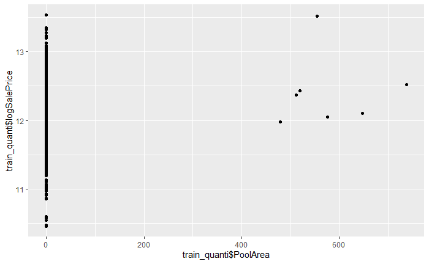

```r
qplot(train_quanti$PoolArea,train_quanti$logSalePrice)
```

Pour la Pool, Je remarque qu’il y a peu de maison avec Pool, et que cela n’a pas bcp d’influence sur le SalePrice Peut-être pouvons nous remplacer les deux features sur la Pool par un booléen qui mentionne si la maison a une Pool (1) ou si elle n’en a pas (0)

```r
# code pour changer les features PoolQC, PoolArea
levels(train_quali$PoolQC)<-c(levels(train_quali$PoolQC),0, 1)

train_quali$PoolQC[is.na(train_quali$PoolQC)] <- 0
train_quali$PoolQC[train_quali$PoolQC=="Ex"] <- 1
train_quali$PoolQC[train_quali$PoolQC=="Fa"] <- 1
train_quali$PoolQC[train_quali$PoolQC=="Gd"] <- 1

train_quanti <- select(train_quanti, -PoolArea)
train_quali$Pool <- train_quali$PoolQC
train_quali <- select(train_quali, -PoolQC)
summary(train_quali$Pool)
```

```
  Ex   Fa   Gd    0    1
   0    0    0 1453    7
```

On travaille maintenant sur la feature “FireplaceQu” qui est lié à la feature quanti “FirePlaces”

```r
summary(train_quanti$Fireplaces)
```

```
   Min. 1st Qu.  Median    Mean 3rd Qu.    Max.
  0.000   0.000   1.000   0.613   1.000   3.000
```

FirePlaces oscille en 0 et 3 et FireplaceQu est une échelle de qualité entre excellent et Poor (et None quand il n’y en a pas) On pourrait peut etre remplacer FireplaceQu par une échelle allant de 0 à 5 et on pondère par le nombre de FirePlaces ?

exemple : si FirePlaces =2 et FireplaceQu =excellent(ou 5), on aurait une nouvelle FireplaceQu = 10

```r
# code pour modifier FirePlaces et FireplaceQU
levels(train_quali$FireplaceQu)<-c(levels(train_quali$FireplaceQu), 0, 1, 2, 3, 4, 5)

train_quali$FireplaceQu[is.na(train_quali$FireplaceQu)] <- 0
train_quali$FireplaceQu[train_quali$FireplaceQu=="TA"] <- 1
train_quali$FireplaceQu[train_quali$FireplaceQu=="Po"] <- 2
train_quali$FireplaceQu[train_quali$FireplaceQu=="Gd"] <- 3
train_quali$FireplaceQu[train_quali$FireplaceQu=="Fa"] <- 4
train_quali$FireplaceQu[train_quali$FireplaceQu=="Ex"] <- 5

summary(train_quali$FireplaceQu)
```

```
 Ex  Fa  Gd  Po  TA   0   1   2   3   4   5
  0   0   0   0   0 690 313  20 380  33  24
```

```r
# Pour l'instant, je ne pondère pas par le nbre de FirePlaces
```

Dans la description, les features Fence et MiscFeature ne sont reliés à aucune autre feature Donc, on reste à la seule modification des “NA” en “none”

#### On travaille maintenant sur les autres features qualitatives

On étudie la description des features de Kaggle

```r
# voir pour Kitchen (pareil que pour FirePlaces)
summary(train_quali$KitchenQual)
```

```
 Ex  Fa  Gd  TA
100  39 586 735
```

```r
summary(train_quanti$KitchenAbvGr)
```

```
   Min. 1st Qu.  Median    Mean 3rd Qu.    Max.
  0.000   1.000   1.000   1.047   1.000   3.000
```

```r
# Je ne pense pas toucher aux features sur la Kitchen

# pour Garage, des features qui se repètent donc voir pour en enlever
```

Pour les features concernant le Garage : changement que pour GarageQual et GarageCond faire échelle de valeur de 0 à 5 pour chaque feature et additionner les deux notes, ça donnera une note générale de la qualité du garage

```r
summary(train_quali$GarageQual)
```

```
  Ex   Fa   Gd   Po   TA NA's
   3   48   14    3 1311   81
```

```r
summary(train_quali$GarageCond)
```

```
  Ex   Fa   Gd   Po   TA NA's
   2   35    9    7 1326   81
```

```r
# code pour les features GarageQual et GarageCond
levels(train_quali$GarageQual)<-c(levels(train_quali$GarageQual), 0, 1, 2, 3, 4, 5)

train_quali$GarageQual[is.na(train_quali$GarageQual)] <- 0
train_quali$GarageQual[train_quali$GarageQual=="TA"] <- 1
train_quali$GarageQual[train_quali$GarageQual=="Po"] <- 2
train_quali$GarageQual[train_quali$GarageQual=="Gd"] <- 3
train_quali$GarageQual[train_quali$GarageQual=="Fa"] <- 4
train_quali$GarageQual[train_quali$GarageQual=="Ex"] <- 5

summary(train_quali$GarageQual)
```

```
  Ex   Fa   Gd   Po   TA    0    1    2    3    4    5
   0    0    0    0    0   81 1311    3   14   48    3
```

```r
levels(train_quali$GarageCond)<-c(levels(train_quali$GarageCond), 0, 1, 2, 3, 4, 5)

train_quali$GarageCond[is.na(train_quali$GarageCond)] <- 0
train_quali$GarageCond[train_quali$GarageCond=="TA"] <- 1
train_quali$GarageCond[train_quali$GarageCond=="Po"] <- 2
train_quali$GarageCond[train_quali$GarageCond=="Gd"] <- 3
train_quali$GarageCond[train_quali$GarageCond=="Fa"] <- 4
train_quali$GarageCond[train_quali$GarageCond=="Ex"] <- 5

summary(train_quali$GarageCond)
```

```
  Ex   Fa   Gd   Po   TA    0    1    2    3    4    5
   0    0    0    0    0   81 1326    7    9   35    2
```

```r
train_quali$GarageQual <- as.numeric(train_quali$GarageQual)
train_quali$GarageCond <- as.numeric(train_quali$GarageCond)


summary(train_quali$GarageQual)
```

```
   Min. 1st Qu.  Median    Mean 3rd Qu.    Max.
  6.000   7.000   7.000   7.073   7.000  11.000
```

```r
summary(train_quali$GarageCond)
```

```
   Min. 1st Qu.  Median    Mean 3rd Qu.    Max.
  6.000   7.000   7.000   7.039   7.000  11.000
```

```r
train_quali$GarageQual <- train_quali$GarageQual + train_quali$GarageCond - 12

summary(train_quali$GarageQual)
```

```
   Min. 1st Qu.  Median    Mean 3rd Qu.    Max.
  0.000   2.000   2.000   2.112   2.000  10.000
```

```r
train_quali <- select(train_quali, -GarageCond)

summary(train_quali$GarageQual)
```

```
   Min. 1st Qu.  Median    Mean 3rd Qu.    Max.
  0.000   2.000   2.000   2.112   2.000  10.000
```

Même travail sur ExterQual et ExterCond

```r
# même code que pour les features sur le garage, comme ça on aura une note sur 10 de la qualité de ExterQual
```

Features Exterior1st et Exterior2nd

```r
summary(train_quali$Exterior1st)
```

```
AsbShng AsphShn BrkComm BrkFace  CBlock CemntBd HdBoard ImStucc MetalSd Plywood   Stone  Stucco VinylSd
     20       1       2      50       1      61     222       1     220     108       2      25     515
Wd Sdng WdShing
    206      26
```

```r
summary(train_quali$Exterior2nd)
```

```
AsbShng AsphShn Brk Cmn BrkFace  CBlock CmentBd HdBoard ImStucc MetalSd   Other Plywood   Stone  Stucco
     20       3       7      25       1      60     207      10     214       1     142       5      26
VinylSd Wd Sdng Wd Shng
    504     197      38
```

```r
table(train_quali$Exterior1st, train_quali$Exterior2nd)
```

```
          AsbShng AsphShn Brk Cmn BrkFace CBlock CmentBd HdBoard ImStucc MetalSd Other Plywood Stone Stucco
  AsbShng      17       0       0       0      0       0       0       0       0     0       2     0      1
  AsphShn       0       1       0       0      0       0       0       0       0     0       0     0      0
  BrkComm       0       0       2       0      0       0       0       0       0     0       0     0      0
  BrkFace       1       0       0      24      0       0       3       0       0     0       6     2      1
  CBlock        0       0       0       0      1       0       0       0       0     0       0     0      0
  CemntBd       0       0       0       0      0      59       0       0       0     0       0     0      0
  HdBoard       0       1       0       0      0       0     193       2       1     0      23     0      0
  ImStucc       0       0       0       0      0       0       0       1       0     0       0     0      0
  MetalSd       0       1       0       0      0       0       3       0     212     0       0     0      1
  Plywood       0       0       5       0      0       0       2       3       0     0      96     0      0
  Stone         0       0       0       0      0       0       1       0       0     0       0     1      0
  Stucco        0       0       0       0      0       1       0       0       0     0       0     1     20
  VinylSd       1       0       0       0      0       0       1       1       0     1       2     0      1
  Wd Sdng       1       0       0       1      0       0       2       3       1     0       8     1      1
  WdShing       0       0       0       0      0       0       2       0       0     0       5     0      1

          VinylSd Wd Sdng Wd Shng
  AsbShng       0       0       0
  AsphShn       0       0       0
  BrkComm       0       0       0
  BrkFace       0      12       1
  CBlock        0       0       0
  CemntBd       0       1       1
  HdBoard       0       1       1
  ImStucc       0       0       0
  MetalSd       0       2       1
  Plywood       0       2       0
  Stone         0       0       0
  Stucco        0       0       3
  VinylSd     502       1       5
  Wd Sdng       2     177       9
  WdShing       0       1      17
```

On remarque ces deux features sont quasiment identiques On prend donc la décision d’en enlever une et de ne garder que Exterior1st

```r
# Code pour supprimer Exterior2nd
train_quali<-select(train_quali, -Exterior2nd)
```

Même travail avec Condition1 et Condition2

```r
summary(train_quali$Condition1)
```

```
Artery  Feedr   Norm   PosA   PosN   RRAe   RRAn   RRNe   RRNn
    48     81   1260      8     19     11     26      2      5
```

```r
summary(train_quali$Condition2)
```

```
Artery  Feedr   Norm   PosA   PosN   RRAe   RRAn   RRNn
     2      6   1445      1      2      1      1      2
```

```r
table(train_quali$Condition1, train_quali$Condition2)
```

```
         Artery Feedr Norm PosA PosN RRAe RRAn RRNn
  Artery      2     0   45    1    0    0    0    0
  Feedr       0     1   76    0    0    1    1    2
  Norm        0     0 1260    0    0    0    0    0
  PosA        0     0    8    0    0    0    0    0
  PosN        0     0   17    0    2    0    0    0
  RRAe        0     0   11    0    0    0    0    0
  RRAn        0     4   22    0    0    0    0    0
  RRNe        0     0    2    0    0    0    0    0
  RRNn        0     1    4    0    0    0    0    0
```

La feature Condition2 n’apporte pas plus d’info puisque la feature est pratiquement tjrs “Norm” On décide de supprimer la feature Condition2

```r
# code pour supprimer la feature Condition2
train_quali<-select(train_quali, -Condition2)
```

##### Travail sur les features Bsmt (BsmtQual BsmtCond BsmtExposure BsmtFinType1 BsmtFinType2)

Dans les variables quanti, Il existe une colonne “TotalBsmtSF” qui est égale à la somme de 3 features

Donc on reprend la même idée : * en convertissant les ratings de BsmtFinType1 et BsmtFinType2 en note allant de 0 à 6 * en additionnant les deux features pour avoir une note globale

```r
# code pour modifier les features BsmtFinType1 et BsmtFinType2
```

## Fin du travai sur les variables qualitatives

```r
train_quanti<-select_if(trainfull, is.numeric)
# Nombre de "NA" dans chaque colonne de train_quanti
colSums(is.na(train_quanti))
```

```
           Id    MSSubClass   LotFrontage       LotArea   OverallQual   OverallCond     YearBuilt
            0             0           259             0             0             0             0
 YearRemodAdd    MasVnrArea    BsmtFinSF1    BsmtFinSF2     BsmtUnfSF   TotalBsmtSF     X1stFlrSF
            0             8             0             0             0             0             0
    X2ndFlrSF  LowQualFinSF     GrLivArea  BsmtFullBath  BsmtHalfBath      FullBath      HalfBath
            0             0             0             0             0             0             0
 BedroomAbvGr  KitchenAbvGr  TotRmsAbvGrd    Fireplaces   GarageYrBlt    GarageCars    GarageArea
            0             0             0             0            81             0             0
   WoodDeckSF   OpenPorchSF EnclosedPorch    X3SsnPorch   ScreenPorch      PoolArea       MiscVal
            0             0             0             0             0             0             0
       MoSold        YrSold     SalePrice
            0             0             0
```